# Modeling workflow: NLA N2O survey data

# 5 Population estimates

A number of estimates for the target population were assembled and presented below. First, the full posterior predictive distributions for dissolved N2O, equilibrium N2O, and the saturation ratio were assessed. These distributions summarized the predicted distribution of concentrations or ratios for all lakes in the population of interest and included parameter uncertainty propagated through the model. Next, population means were assessed, followed by comparisons of some model-based estimates to previously calculated design-based estimates.

## 5.1 Posterior predictive distributions

Below, a density plot summarized the posterior predictive distributions across the target population of lakes. The summaries of the PPDs were based on 2000 draws. Note that the x-axis was truncated at 50 nmol/L for a clearer visualization of the bulk of the predictive distribution. For reference, the max predicted value was 4403.2 nmol/L for dissolved N2O, 20.4 nmol/L for dissolved N2O, and 793.5 for the saturation ratio.

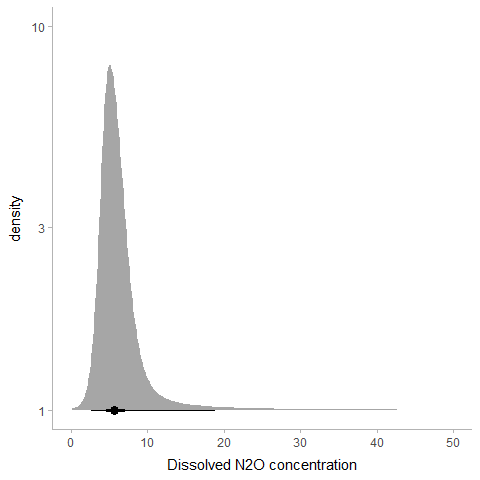

[figure not shown]

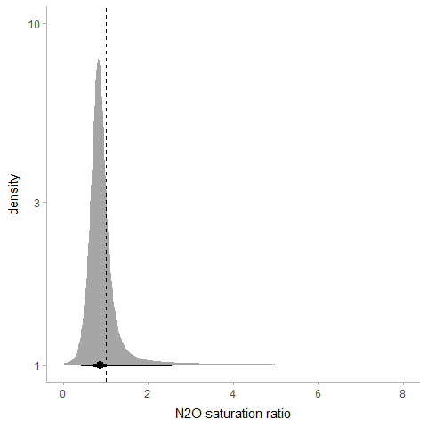

## 5.2 Estimated means

### 5.2.1 National

Below are density plots summarizing the posterior distribution of *means* for N2O concentrations and the saturation ratio for all US lakes and reservoirs > 4ha in the lower 48 states).

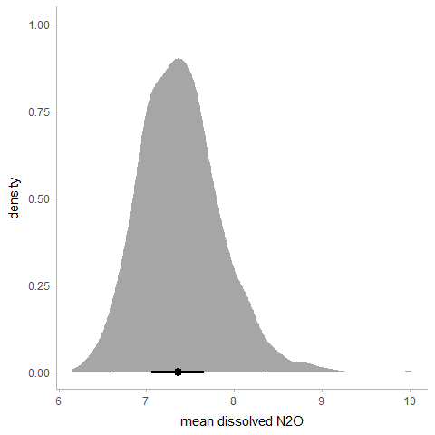

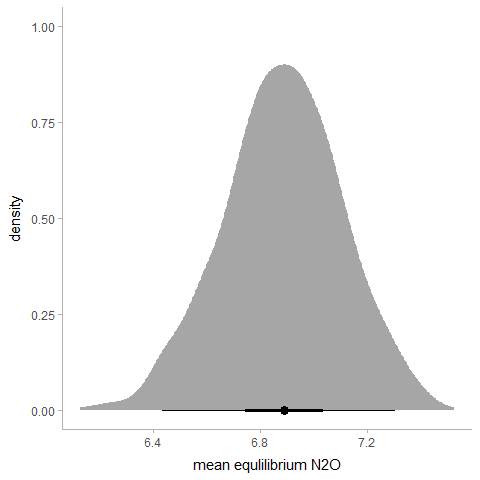

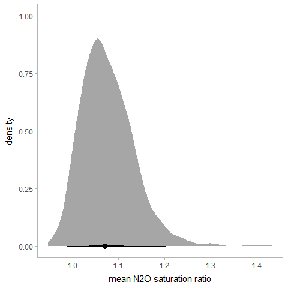

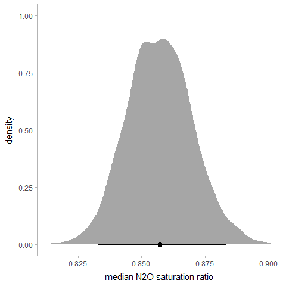

Below is a plot of the posterior mean estimate for the proportion of unsaturated lakes at the national scale.

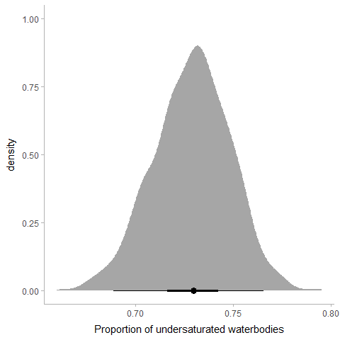

### 5.2.2 Ecoregion

Below are posterior estimates of the means for dissolved and equilibrium N2O and the saturation ratio by WSA9 ecoregion.

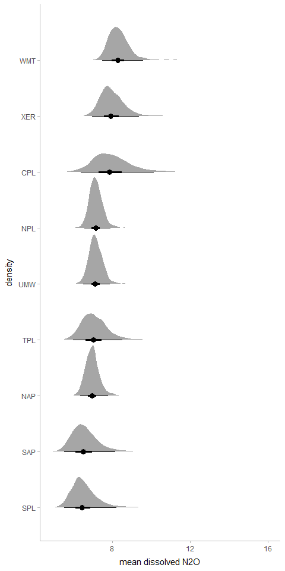

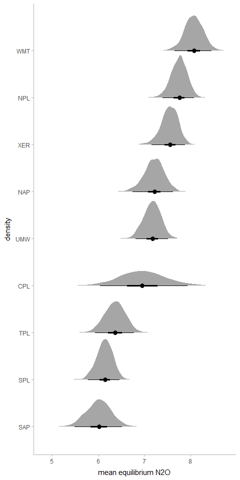

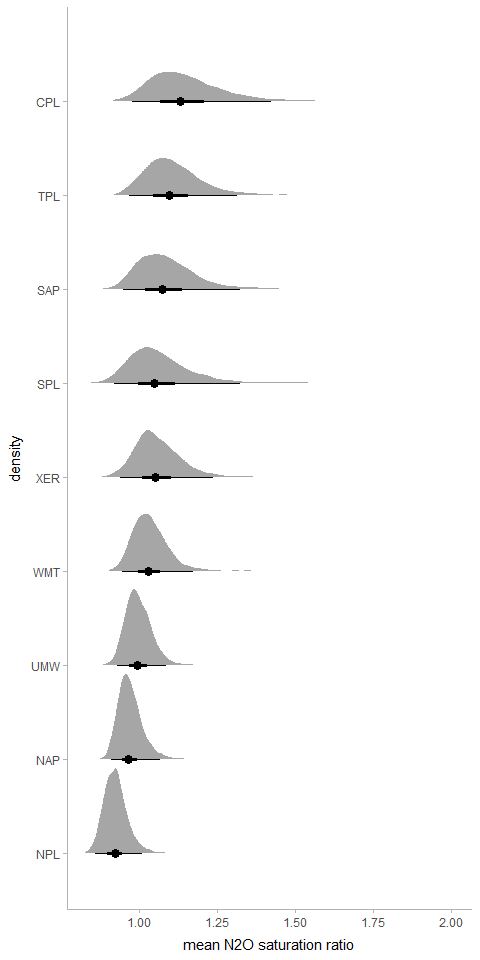

A plot of the posterior estimates for the median saturation ratio below indicated that most lakes in each ecoregion were undersaturated (i.e., median < 1).

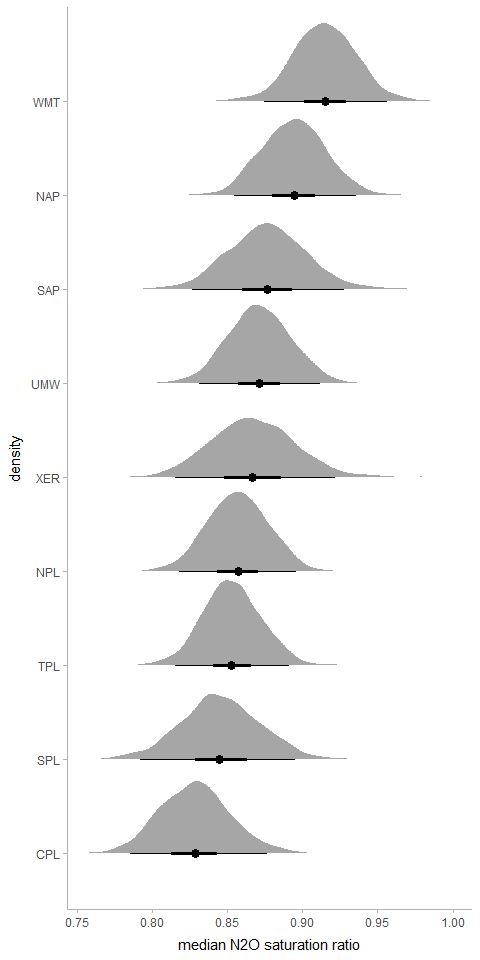

A plot of the estimates of the proportion of under-saturated lakes by ecoregion is below. These summaries again suggested that most lakes in each ecoregion were likely undersaturated (i.e., median << 1).

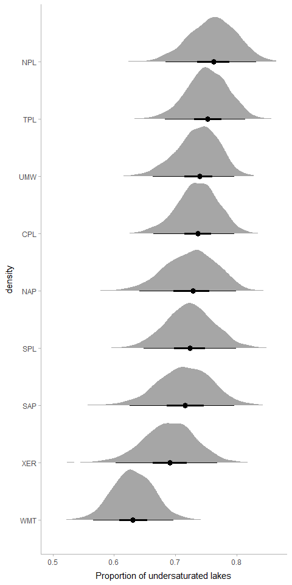

### 5.2.3 State

Comparisons of mean estimates by state are below. Density polygons were not included to minimize the vertical plot space.

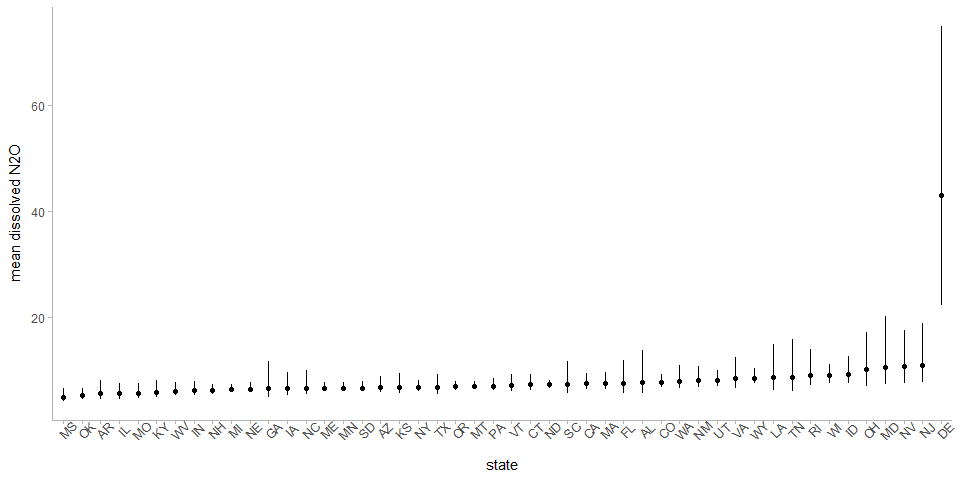

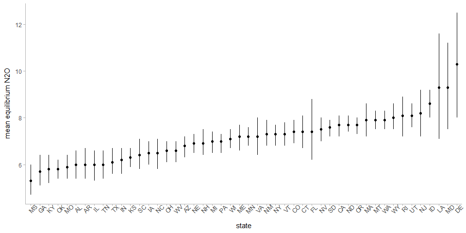

Below is a plot of estimates for the mean (black circles) and median (grey circles) saturation ratio by state. A horizontal, dashed, black line is shown at ratio = 1, indicating the boundary for under- *vs.* oversaturation. Only a few states (e.g., NV, DE) had median estimates that were 1 or greater, suggesting that, for most states, most lakes were estimated to be undersaturated.

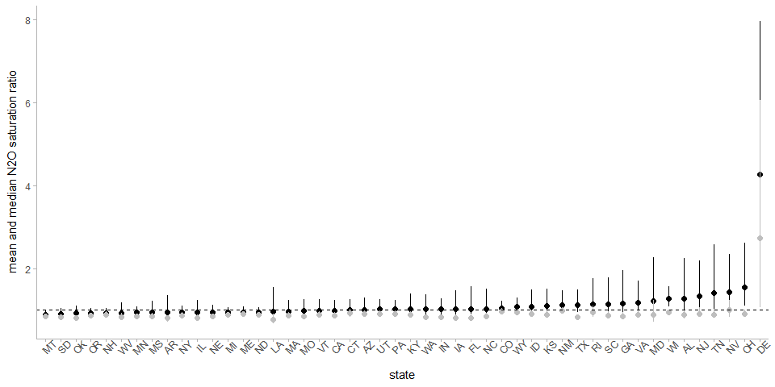

Finally, a plot of the estimated proportion of undersaturated lakes for each state in the target population. Point estimates are the posterior median of the proportion and bars are the upper and lower boundaries of the central 95th percentile of the posterior distributions of proportions.

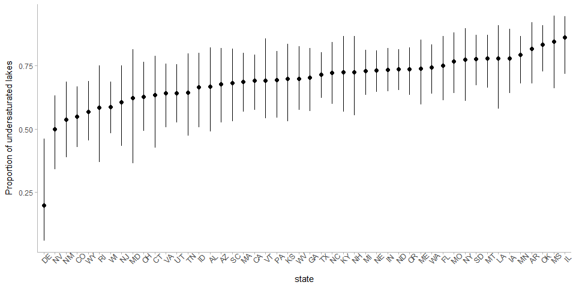

### 5.2.4 Size category

The estimated means and medians by size category are below for dissolved and equilibrium N2O and the saturation ratio.

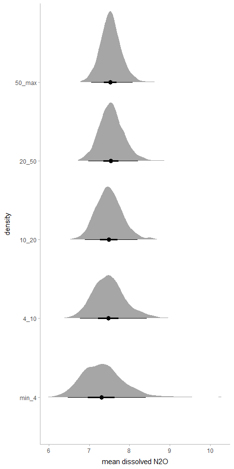

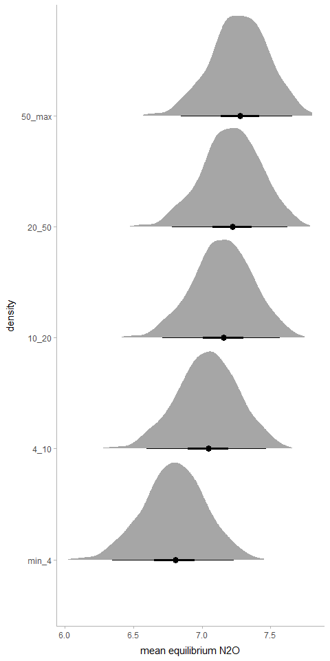

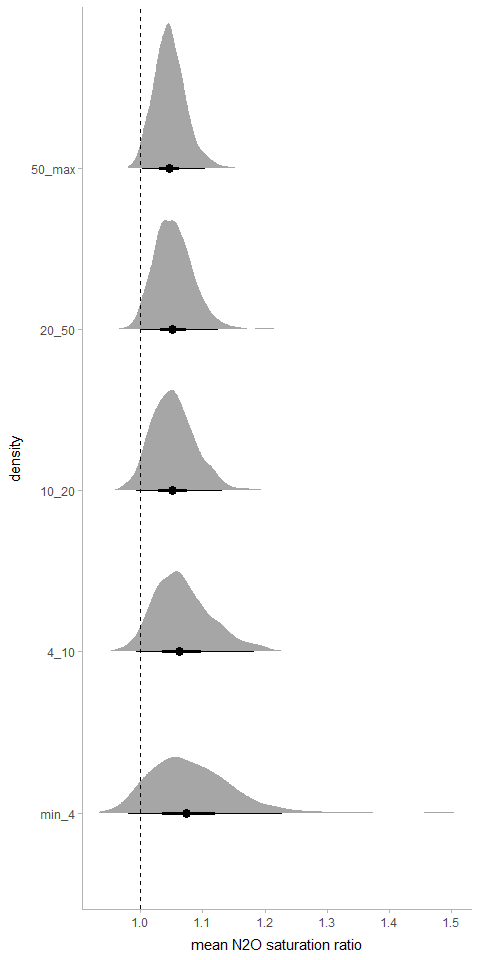

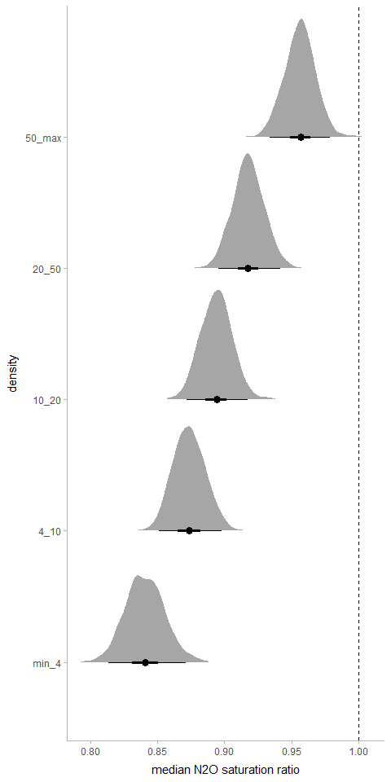

Mean *vs.* median below.

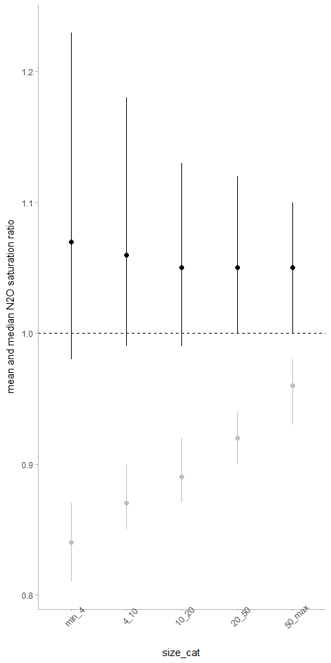

And, finally, the estimated proportion of undersaturated lakes in the target population by size category.

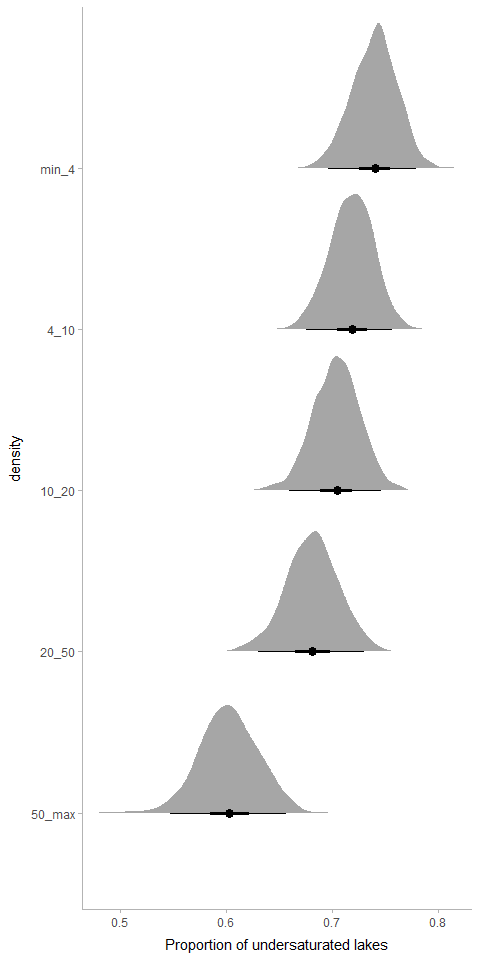

## 5.3 Model- *vs.* design-based

### 5.3.1 Dissolved N2O

Below, National mean estimates for dissolved N2O from the model and design-based approaches were compared. The code and results for the design-based approach are located at: https://github.com/USEPA/DissolvedGasNla/tree/master/scripts

The sample-based estimates were also included as a reference and are represented by the black, vertical, dashed lines.

```r
### Dissolved N2O estimates

n2o_survey_ests <- read.csv(file = "./../inputData/populationEstimates/Survey_Ests_N20_dissolved.csv") %>%
  tibble() %>%
  rename(estimate = Estimate,
         LCL = LCB95Pct,
         UCL = UCB95Pct) %>%
  select(Type, Subpopulation, estimate, LCL, UCL)

# ests by subpopulations
n2o_survey_ecoregion <- n2o_survey_ests %>%
  filter(Type == "AG_ECO9_NM") %>%
  rename(ecoregion = Subpopulation) %>%
  select(ecoregion, estimate, LCL, UCL) %>%
  mutate(ecoregion = recode(ecoregion,
                            "Coastal Plains" = "CPL",
                            "Northern Appalachians" = "NAP",
                            "Northern Plains" = "NPL",
                            "Southern Appalachians" = "SAP",
                            "Southern Plains" = "SPL",
                            "Temperate Plains" = "TPL",
                            "Upper Midwest" = "UMW",
                            "Western Mountains" = "WMT",
                            "Xeric" = "XER"))

n2o_survey_size <- n2o_survey_ests %>%
  filter(Type == "AREA_CAT6") %>%
  rename(size_cat = Subpopulation) %>%
  select(size_cat, estimate, LCL, UCL)

### Saturation ratio estimates
sat_survey_ests <- read.csv(file = "./../inputData/populationEstimates/Survey_Ests_N20_sat.csv") %>%
  tibble() %>%
  rename(estimate = Estimate,
         LCL = LCB95Pct,
         UCL = UCB95Pct) %>%
  select(Type, Subpopulation, estimate, LCL, UCL)
```

```
## # A tibble: 3 × 4
##   estimate   LCL   UCL type
##      <dbl> <dbl> <dbl> <chr>
## 1     7.35  6.59  8.37 model
## 2     8.05  7.02  9.09 survey
## 3     8.72 NA    NA    sample
```

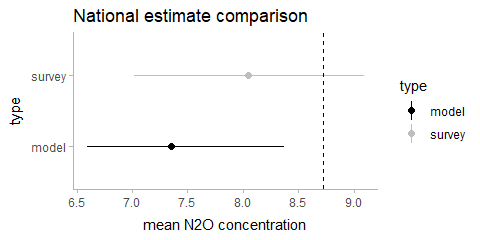

```r
all_predictions %>%
  group_by(.draw) %>%
  summarise(mean_n2o = mean(n2o)) %>%
  summarise(estimate = round(median(mean_n2o), 2), # posterior median
    LCL = round(quantile(mean_n2o, probs = 0.025), 2),
    UCL = round(quantile(mean_n2o, probs = 0.975), 2)) %>%
  mutate(type = "model") %>%
  bind_rows(cbind(n2o_survey_ests[1, 3:5], type = rep("survey", 1))) %>%
  add_row(estimate = round(mean(df_model$n2o), 2),
          type = "sample") %>%
  print()
```

Below, estimates were compared by ecoregion.

```
## # A tibble: 18 × 5
##    ecoregion estimate   LCL   UCL type
##    <chr>        <dbl> <dbl> <dbl> <chr>
##  1 CPL           7.87  6.39 10.1  model
##  2 CPL           8.4   5.13 11.7  survey
##  3 NAP           6.96  6.37  7.78 model
##  4 NAP           7.65  7.21  8.09 survey
##  5 NPL           7.15  6.58  7.9  model
##  6 NPL           6.89  6.39  7.4  survey
##  7 SAP           6.51  5.54  8.14 model
##  8 SAP           7.06  5.93  8.18 survey
##  9 SPL           6.45  5.54  8.23 model
## 10 SPL           6.51  4.89  8.13 survey
## 11 TPL           7.02  6     8.52 model
## 12 TPL           7.77  5.94  9.6  survey
## 13 UMW           7.13  6.53  7.88 model
## 14 UMW          10.8   6.39 15.2  survey
## 15 WMT           8.28  7.49  9.59 model
## 16 WMT           7.75  7.12  8.38 survey
## 17 XER           7.91  6.98  9.38 model
## 18 XER          10.6   7.53 13.6  survey
```

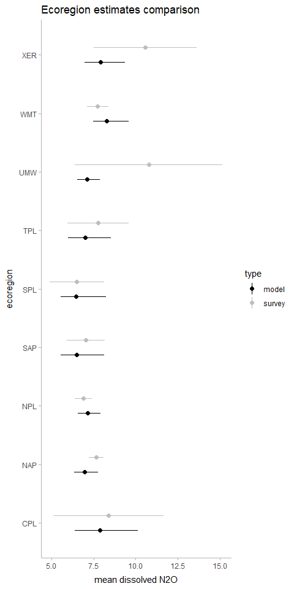

```r
all_predictions %>%
  group_by(WSA9, .draw) %>%
  summarise(mean_n2o = mean(n2o)) %>%
  group_by(WSA9, .groups = "drop") %>%
  summarise(estimate = round(median(mean_n2o), 2),
    LCL = round(quantile(mean_n2o, probs = 0.025), 2),
    UCL = round(quantile(mean_n2o, probs = 0.975), 2),
    .groups = "drop") %>%
  mutate(ecoregion = factor(WSA9)) %>%
  mutate(type = "model") %>%
  select(ecoregion, estimate, LCL, UCL, type) %>%
  mutate(ecoregion = forcats::fct_reorder(ecoregion, estimate)) %>%
  bind_rows(cbind(n2o_survey_ecoregion, type = rep("survey", 9))) %>%
  #bind_rows(cbind(n2o_survey_ests[-10,], type = rep("survey", 9))) %>%
  arrange(ecoregion) %>%
  print()
```

Means were compared according to size categories below.

```
## # A tibble: 10 × 5
##    size   estimate   LCL   UCL type
##    <fct>     <dbl> <dbl> <dbl> <chr>
##  1 10_20      7.5   6.9   8.2  model
##  2 10_20      7.6   7.13  8.08 survey
##  3 4_10       7.5   6.8   8.4  model
##  4 4_10       7.64  6.51  8.78 survey
##  5 50_max     7.5   7     8.1  model
##  6 50_max     7.95  7.44  8.47 survey
##  7 min_4      7.3   6.5   8.4  model
##  8 min_4      8.17  6.41  9.92 survey
##  9 20_50      7.5   7     8.2  model
## 10 20_50      8.57  7.67  9.47 survey
```

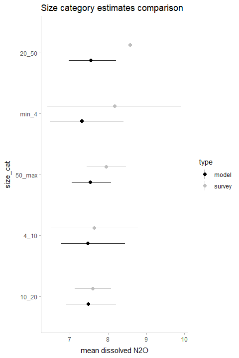